# Machine Learning Project Trial

Skye Liu

11/30/2021

## Set up

```r
# Import libraries
library(gam)
library(neuralnet)
library(rpart)
library(rattle)
library(randomForest)
library(caret)
library(xgboost)
library(cluster)
library(tidyverse)
library(OptimalCutpoints)
library(pROC)
# Read in data
total_data <- read.csv("Airline_customer_experience.csv",
                       header = T, stringsAsFactors = T)

# Remove missing value & index column
total_data <- total_data[-which(is.na(total_data), arr.ind=TRUE), -1]

# Check if the data is imbalanced
total_obs <- dim(total_data)[1]
sum(total_data$Satisfaction == "dissatisfied") / total_obs
```

```
## [1] 0.4512358
```

```r
# Create train & test data
set.seed(7)
train_data_indices <- sample(1:total_obs, 0.7*total_obs)
train_data <- total_data[train_data_indices, ]
test_data <- total_data[-train_data_indices, ]
```

## Clustering

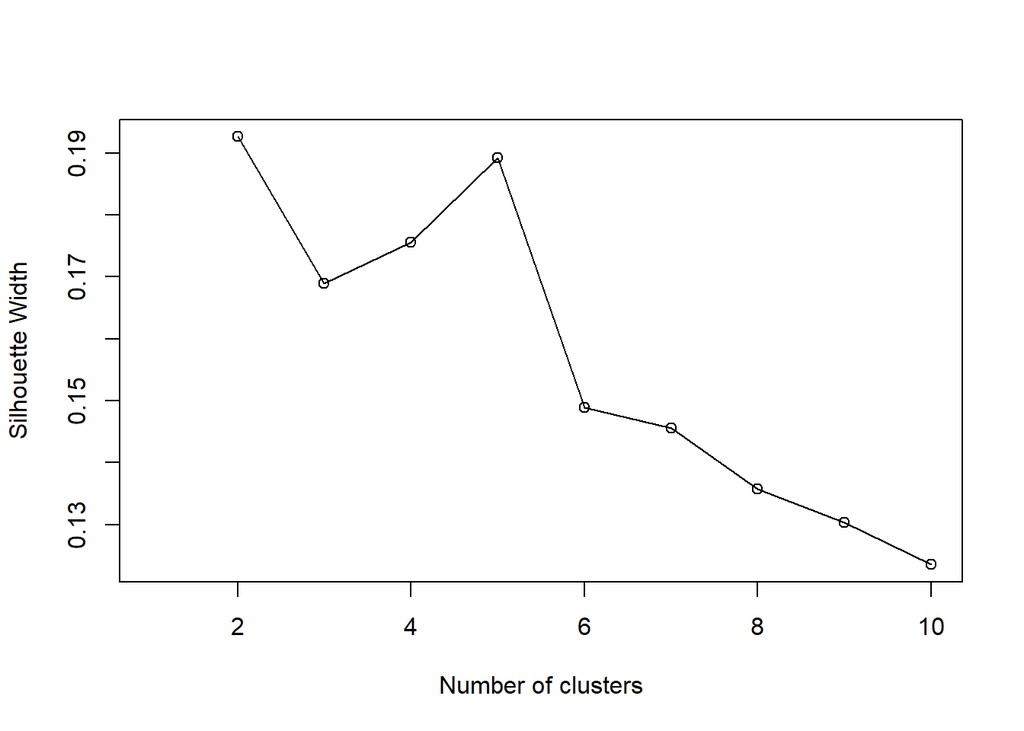

```r
gower_dist <- daisy(total_data,
                    metric = "gower")
gower_mat <- as.matrix(gower_dist)

# Calculate silhouette width for many k using PAM
sil_width <- c(NA)
for(i in 2:10){
  pam_fit <- pam(gower_dist,
                 diss = TRUE,
                 k = i)
  sil_width[i] <- pam_fit$silinfo$avg.width
}

# Plot silhouette width
plot(1:10, sil_width,
     xlab = "Number of clusters",
     ylab = "Silhouette Width")
lines(1:10, sil_width)
```

```r
total_data_s <- total_data
for(i in 1:ncol(total_data_s)){
  if(is.numeric(total_data_s[,i])){
    total_data_s[,i] <- scale(total_data_s[,i])
  }}
```

Even though the silhouette width is highest when the number of clusters is two, we should not use two as the clusters are too few to differentiate customers. As five clusters give a relatively high width and five is an appropriate number of clusters, we should group customers into 5 segments in this case.

```r
pam_fit <- pam(total_data_s[,c(2:7)], k = 5)

centers <- pam_fit$medoids

# Scale back age and distance for observations
age_mean <- mean(total_data$Age)
age_sd <- sd(total_data$Age)
Flight.Distance_mean <- mean(total_data$Flight.Distance)
Flight.Distance_sd <- sd(total_data$Flight.Distance)

# Create a vector of cluster numbers
clusters <- c(1: 5)

# Extract centers
center_df <- data.frame(clusters, centers)
names(center_df)
```

```
## [1] "clusters"        "Gender"          "Customer.Type"   "Age"
## [5] "Type.of.Travel"  "Class"           "Flight.Distance"
```

```r
center_df$Age <- (center_df$Age * age_sd) + age_mean
center_df$Flight.Distance <- (center_df$Flight.Distance * Flight.Distance_sd) + Flight.Distance_mean

# print a table of features for each cluster
center_df
```

```
##      clusters Gender Customer.Type Age Type.of.Travel Class Flight.Distance
## 2905        1      1             2  54              2     2             840
## 1638        2      1             1  27              1     2            1913
## 1665        3      2             2  41              1     1            3383
## 2464        4      2             2  26              2     2            2125
## 1494        5      2             2  48              1     1            1481
```

In order to maintain business success, companies should always examine the experience of high-value customers. For an airline, customers who bring the most value should be those who are loyal, fly long distance, and better in business class. Therefore, according to the values in `Customer.Type`, `Class`, and `Flight.Distance` shown above, the high-value customer segmentation should be cluster 3. Next, we will examine where the airline needs to make progress for cluster 3.

## Examine Cluster 3 Customer Experience Issue

Based on the variable importance analysis at the end of this file, we know that cluster 3 customers care most about `Inflight.entertainment`, `Ease.of.Online.Booking`, and `Seat.comfort`.

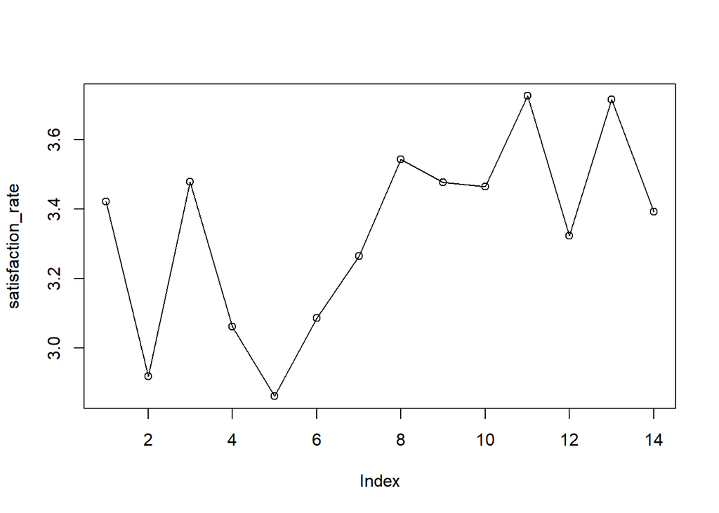

```r
# Check important variables for cluster 3
ie_3 <- mean(total_data$Inflight.entertainment[clusters == 3])
sc_3 <- mean(total_data$Seat.comfort[clusters == 3])
obs_3 <- mean(total_data$On.board.service[clusters == 3])

# Check non-important variables for cluster 4
eoob_3 <- mean(total_data$Ease.of.Online.booking[clusters == 3])
datc_3 <- mean(total_data$Departure.Arrival.time.convenient[clusters == 3])
fad_3 <- mean(total_data$Food.and.drink[clusters == 3])
gl_3 <- mean(total_data$Gate.location[clusters == 3])
iws_3 <- mean(total_data$Inflight.wifi.service[clusters == 3])
os_3 <- mean(total_data$Online.support[clusters == 3])
lrs_3 <- mean(total_data$Leg.room.service[clusters == 3])
bh_3 <- mean(total_data$Baggage.handling[clusters == 3])
cs_3 <- mean(total_data$Checkin.service[clusters == 3])
c_3 <- mean(total_data$Cleanliness[clusters == 3])
ob_3 <- mean(total_data$Online.boarding[clusters == 3])

# Plot Important Ratings for cluster 2
satisfaction_rate <- c(ie_3, sc_3, eoob_3, datc_3, fad_3, gl_3, iws_3, os_3, obs_3, lrs_3, bh_3, cs_3, c_3, ob_3)

plot(satisfaction_rate, type = "o")
```

We can clearly see from the chart that the airline really need to improve their seats for high-value customers.

## Find the Most Dissatisfied Segment

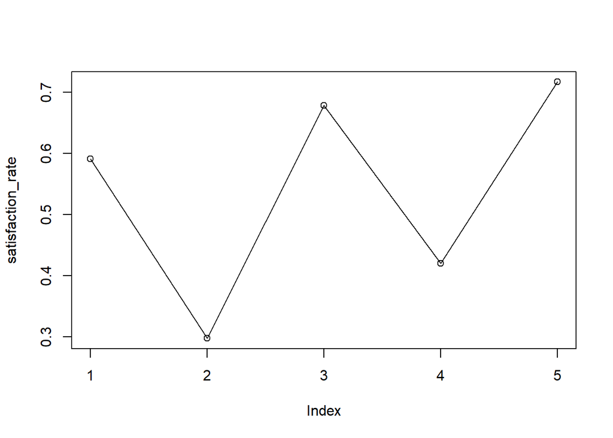

```r
clusters <- pam_fit$clustering

# Check overall satisfaction rate
sats_1 <- mean(total_data$Satisfaction[clusters == 1] == "satisfied")
sats_2 <- mean(total_data$Satisfaction[clusters == 2] == "satisfied")
sats_3 <- mean(total_data$Satisfaction[clusters == 3] == "satisfied")
sats_4 <- mean(total_data$Satisfaction[clusters == 4] == "satisfied")
sats_5 <- mean(total_data$Satisfaction[clusters == 5] == "satisfied")

# Plot satisfaction rate
satisfaction_rate <- c(sats_1, sats_2, sats_3, sats_4, sats_5)
plot(satisfaction_rate, type = "o")
```

From the graph above, cluster 2 is most dissatisfied with the airline experience. Therefore, currently the airline needs to focus on improving the experience of cluster 2 customers.

## Dissatisfaction Reasons for Cluster 2

Based on variable important analysis, the most important variables for cluster 2 are `Inflight.entertainment`, `Seat.comfort`, and `Ease.of.Online.booking`. Therefore, we assume that the low satisfaction rate is mainly due to poor experience in these areas. Assumption tests are as follows.

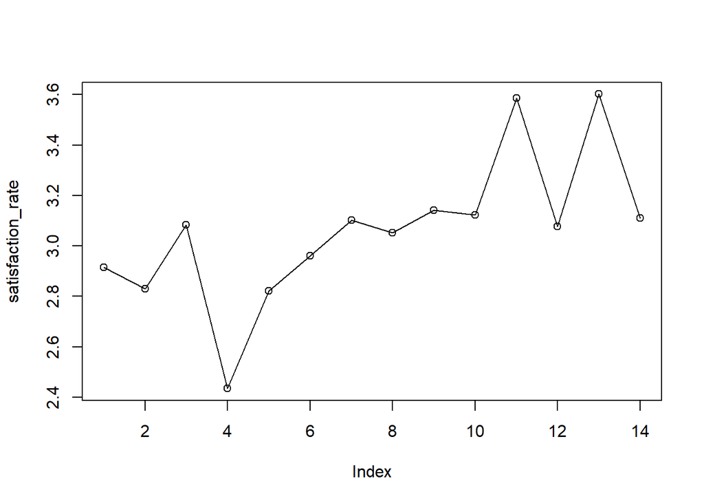

```r
# Check important variables for cluster 3
ie_2 <- mean(total_data$Inflight.entertainment[clusters == 2])
sc_2 <- mean(total_data$Seat.comfort[clusters == 2])
obs_2 <- mean(total_data$On.board.service[clusters == 2])

# Check non-important variables for cluster 4
eoob_2 <- mean(total_data$Ease.of.Online.booking[clusters == 2])
datc_2 <- mean(total_data$Departure.Arrival.time.convenient[clusters == 2])
fad_2 <- mean(total_data$Food.and.drink[clusters == 2])
gl_2 <- mean(total_data$Gate.location[clusters == 2])
iws_2 <- mean(total_data$Inflight.wifi.service[clusters == 2])
os_2 <- mean(total_data$Online.support[clusters == 2])
lrs_2 <- mean(total_data$Leg.room.service[clusters == 2])
bh_2 <- mean(total_data$Baggage.handling[clusters == 2])
cs_2 <- mean(total_data$Checkin.service[clusters == 2])
c_2 <- mean(total_data$Cleanliness[clusters == 2])
ob_2 <- mean(total_data$Online.boarding[clusters == 2])

# Plot Important Ratings for cluster 2
satisfaction_rate <- c(ie_2, sc_2, eoob_2, datc_2, fad_2, gl_2, iws_2, os_2, obs_2, lrs_2, bh_2, cs_2, c_2, ob_2)

plot(satisfaction_rate, type = "o")
```

Baesd on the satisfaction rate chart, we can see `seat.comfort` ratings are the lowest among those of the top 3 needs. `Departure.Arrival.time.convenient` isn’t excellent either, but it does not impact satisfaction as much as `seat.comfort` according to the variable improtance ranking.

## Logistic Regression

```r
lm_full <- glm(Satisfaction~., family = binomial, data = train_data)
```

## Logistic Regression + Backward Selection

```r
lm_bwd <- step(lm_full, direction = 'backward', k = log(nrow(train_data)), trace = T)
```

```
## Start:  AIC=1659.16
## Satisfaction ~ Gender + Customer.Type + Age + Type.of.Travel +
##     Class + Flight.Distance + Seat.comfort + Departure.Arrival.time.convenient +
##     Food.and.drink + Gate.location + Inflight.wifi.service +
##     Inflight.entertainment + Online.support + Ease.of.Online.booking +
##     On.board.service + Leg.room.service + Baggage.handling +
##     Checkin.service + Cleanliness + Online.boarding + Departure.Delay.in.Minutes +
##     Arrival.Delay.in.Minutes
##
##                                     Df Deviance    AIC
## - Online.support                     1   1475.7 1651.6
## - Inflight.wifi.service              1   1475.7 1651.6
## - Cleanliness                        1   1476.1 1652.0
## - Age                                1   1476.2 1652.1
## - Flight.Distance                    1   1477.5 1653.3
## - Gate.location                      1   1478.0 1653.9
## - Baggage.handling                   1   1478.2 1654.0
## - Online.boarding                    1   1479.9 1655.8
## - Departure.Delay.in.Minutes         1   1481.7 1657.6
## - Food.and.drink                     1   1481.8 1657.6
## <none>                                   1475.6 1659.2
## - Arrival.Delay.in.Minutes           1   1483.6 1659.5
## - Departure.Arrival.time.convenient  1   1486.3 1662.2
## - On.board.service                   1   1487.0 1662.9
## - Ease.of.Online.booking             1   1489.4 1665.3
## - Seat.comfort                       1   1490.8 1666.7
## - Leg.room.service                   1   1494.3 1670.2
## - Type.of.Travel                     1   1494.4 1670.3
## - Class                              2   1510.2 1678.5
## - Checkin.service                    1   1519.5 1695.4
## - Gender                             1   1538.5 1714.4
## - Customer.Type                      1   1597.6 1773.5
## - Inflight.entertainment             1   1612.9 1788.8
##
## Step:  AIC=1651.58
## Satisfaction ~ Gender + Customer.Type + Age + Type.of.Travel +
##     Class + Flight.Distance + Seat.comfort + Departure.Arrival.time.convenient +
##     Food.and.drink + Gate.location + Inflight.wifi.service +
##     Inflight.entertainment + Ease.of.Online.booking + On.board.service +
##     Leg.room.service + Baggage.handling + Checkin.service + Cleanliness +
```

[output cut: 266 more lines]

```
##     Checkin.service
##
##                                     Df Deviance    AIC
## <none>                                   1502.1 1601.5
## - Seat.comfort                       1   1513.3 1605.1
## - Type.of.Travel                     1   1518.0 1609.8
## - On.board.service                   1   1520.1 1611.8
## - Departure.Arrival.time.convenient  1   1521.3 1613.1
## - Leg.room.service                   1   1523.6 1615.4
## - Class                              2   1537.1 1621.2
## - Checkin.service                    1   1560.2 1652.0
## - Gender                             1   1573.4 1665.1
## - Ease.of.Online.booking             1   1589.1 1680.9
## - Customer.Type                      1   1631.7 1723.4
## - Inflight.entertainment             1   1658.8 1750.6
```

## GAM

```r
gam_full <- gam(Satisfaction~Gender+Customer.Type+s(Age)+Type.of.Travel+Class+s(Flight.Distance)+s(Seat.comfort)+s(Departure.Arrival.time.convenient)+s(Food.and.drink)+s(Gate.location)+s(Inflight.wifi.service+Inflight.entertainment)+s(Online.support)+s(Ease.of.Online.booking)+s(On.board.service)+s(Leg.room.service)+s(Baggage.handling)+s(Checkin.service)+s(Cleanliness)+s(Online.boarding)+s(Departure.Delay.in.Minutes)+s(Arrival.Delay.in.Minutes), family='binomial', data=train_data)
```

## Neural Networks

```r
# generate a data frame with categorical predictors being represented as dummy variables
train_db <- na.omit(train_data)

x_train_nn <- model.matrix(~Gender+Customer.Type+Age+Type.of.Travel+Class+Flight.Distance+Seat.comfort+Departure.Arrival.time.convenient+Food.and.drink+Gate.location+Inflight.wifi.service+Inflight.entertainment+Online.support+Ease.of.Online.booking+On.board.service+Leg.room.service+Baggage.handling+Checkin.service+Cleanliness+Online.boarding+Departure.Delay.in.Minutes+Arrival.Delay.in.Minutes, data=train_db)[,-1]

# standardization
x_mean <- apply(x_train_nn, 2, mean)
x_sd <- apply(x_train_nn, 2, sd)
x_train_nn <- scale(x_train_nn, center=x_mean, scale=x_sd)

# combine with dependent variable Log_price
x_train_nn <- cbind.data.frame(train_data$Satisfaction, x_train_nn)
colnames(x_train_nn)[1] <- 'Satisfaction'

# generate and standardize the data frame for test data
x_test_nn <- model.matrix(~Gender+Customer.Type+Age+Type.of.Travel+Class+Flight.Distance+Seat.comfort+Departure.Arrival.time.convenient+Food.and.drink+Gate.location+Inflight.wifi.service+Inflight.entertainment+Online.support+Ease.of.Online.booking+On.board.service+Leg.room.service+Baggage.handling+Checkin.service+Cleanliness+Online.boarding+Departure.Delay.in.Minutes+Arrival.Delay.in.Minutes, data=test_data)[,-1]

# standardization
x_test_nn <- scale(x_test_nn, center=x_mean, scale=x_sd)

# generate the model
names(x_train_nn)[7] <- "ClassEco.Plus"
set.seed(7)
nn_full <- neuralnet(Satisfaction =='satisfied'~GenderMale+Customer.TypeLoyal+Age+Type.of.TravelPersonal+ClassEco+ClassEco.Plus+Flight.Distance+Seat.comfort+Departure.Arrival.time.convenient+Food.and.drink+Gate.location+Inflight.wifi.service+Inflight.entertainment+Online.support+Ease.of.Online.booking+On.board.service+Leg.room.service+Baggage.handling+Checkin.service+Cleanliness+Online.boarding+Departure.Delay.in.Minutes+Arrival.Delay.in.Minutes, data=x_train_nn, hidden=4, linear.output=F)
```

## Decision Tree

```r
# Check imbalanced data
sum(train_data$Satisfaction == 'satisfied') / nrow(train_data) # The data is balanced.
```

```
## [1] 0.5546539
```

[figure not shown]

```r
# Generate the model
tree_full <- rpart(Satisfaction~.,
data = train_data)

# Plot the tree
fancyRpartPlot(tree_full)
```